# Analyzing Airline Flight Performance: Cancellations & Delays

## Relation Between Arrival Delay & Departure Delay

There is a clear linear relationship between arrival and departure delays, indicating that as departure delay increases, arrival delay also tends to rise proportionally. Consequently, the longer a flight is delayed at departure, the more likely it is to be delayed upon arrival. This direct correlation underscores the importance of minimizing departure delays, as they can have a cascading effect on arrival times, potentially disrupting schedules and affecting subsequent flights.

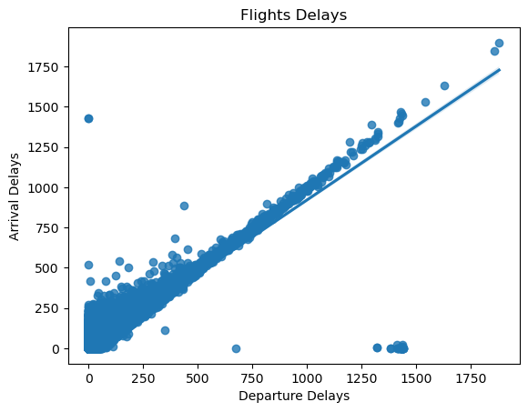

```python
regression_scatter_plot(delay_airline_df,
             ['DepDelayMinutes', 'ArrDelayMinutes'],
             'Flights Delays',
             ['Departure Delays','Arrival Delays'])
```

### Correlation between delay Features, distance and flight time

```python
correlation_columns = [
'DepDelayMinutes',
'ArrDelayMinutes',
'CarrierDelay',
'WeatherDelay',
'NASDelay',
'SecurityDelay',
'LateAircraftDelay',
'DistanceGroup',
'AirTime',
]
```

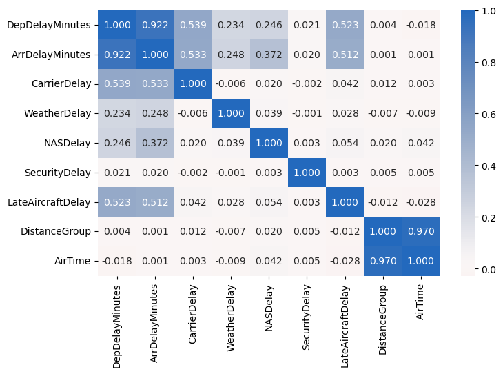

```python
# correlation plot

plt.figure(figsize = [8, 5])
sb.heatmap(delay_airline_df[correlation_columns].corr(), annot = True, fmt = '.3f',
           cmap = 'vlag_r', center = 0)
plt.show()
```

## Conclusion

Analyzing airline flight performance reveals key insights into both cancellations and delays. Cancellations, though relatively rare at 1.8% of total trips, show a higher frequency on Tuesdays and are notably more prevalent in the first quarter of the year. Causes for cancellations are often unspecified, with specific causes like A and B contributing significantly.

Delays present a more complex picture: arrival delays are strongly correlated with departure delays, emphasizing the cascading effect of late departures on arrival times. Late Aircraft Delays, while significant, are less impactful compared to the direct relationship between departure and arrival delays. Furthermore, Distance Group and AirTime exhibit a very strong correlation, reflecting the expected connection between flight distance and duration.

These findings highlight the importance of addressing departure delays to improve overall flight punctuality and managing cancellations effectively to minimize disruption. Understanding these patterns can aid in optimizing flight operations and enhancing passenger experience.